# Task 2.1 R语言的基础练习

郝建锋

2017-10-27

# 1 任务一

## 1.1 载入所需包

```r
library('ggplot2')      # 可视化包
library('ggmap')        # 地图绘制包
library('baidumap')     # 获取百度地图API服务
```

## 1.2 载入并检查数据

```r
dat0 <- read.csv('D:/Desktop/TASK 2.1 数据.csv', stringsAsFactors=F)
summary(dat0)           # 检查数据
```

```
##      CATE                AREA              school          price
##  Length:16795       Min.   :    7.80   Min.   :0.000   Min.   :  5496
##  Class :character   1st Qu.:   59.94   1st Qu.:0.000   1st Qu.: 42701
##  Mode  :character   Median :   78.70   Median :0.000   Median : 57523
##                     Mean   :   95.81   Mean   :0.301   Mean   : 61266
##                     3rd Qu.:  112.08   3rd Qu.:1.000   3rd Qu.: 76336
##                     Max.   :18779.50   Max.   :1.000   Max.   :206667
##       LONG            LAT
##  Min.   :106.0   Min.   :22.34
##  1st Qu.:116.3   1st Qu.:39.89
##  Median :116.4   Median :39.92
##  Mean   :116.4   Mean   :39.89
##  3rd Qu.:116.4   3rd Qu.:39.96
##  Max.   :123.9   Max.   :41.84
```

# 2 任务二

## 2.1 数据清洗

```r
# 删掉面积500以上和单价十五万以上的观测
dat1 <- dat0[which(dat0$AREA<=500 & dat0$price<=150000),]
```

## 2.2 绘制北京二手房单价直方图

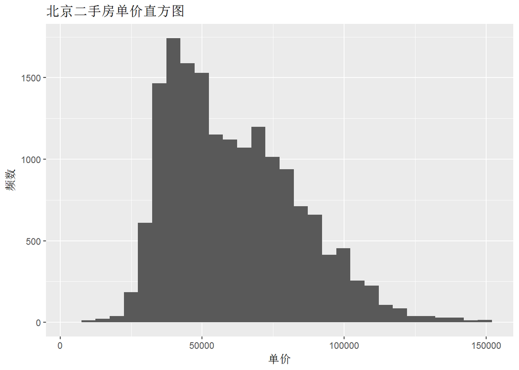

```r
# 绘制直方图
ggplot(dat1, aes(x=price)) +
  geom_histogram() +
  xlab("单价") + ylab("频数") +             # 修改坐标轴标签
  ggtitle("北京二手房单价直方图")           # 添加标题
```

从图中可以看出单价在五万元左右的北京二手房最多，单价三万到十万的二手房占全部房源的80%以上，帝都房价之高可见一般。

# 3 任务三

## 3.1 绘制北京各城区二手房单价箱线图

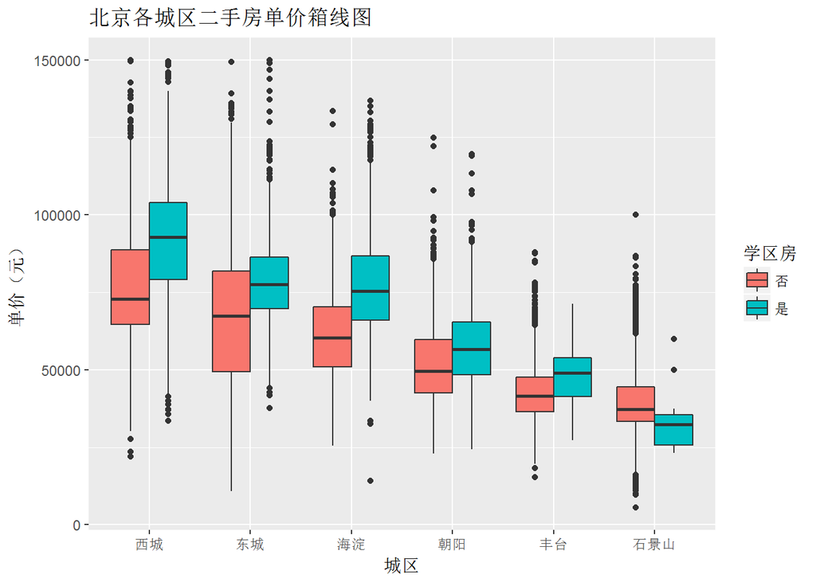

```r
# 为调整x轴刻度标签做准备
order_CATE <- c("xicheng","dongcheng",
                "haidian","chaoyang",
                "fengtai","shijingshan")      # 为X轴因子顺序调节做准备
Chinese_order <- c("西城","东城","海淀",
                   "朝阳","丰台","石景山")    # 为刻度标签中文显示做准备
# 绘制箱线图
ggplot(dat1,aes(x=factor(CATE),y=price,fill=factor(school))) +
  geom_boxplot() +
  # 坐标轴修饰
  scale_x_discrete(limits=order_CATE,
                   labels=Chinese_order) +    # 调整X轴刻度标签
  xlab("城区") + ylab("单价（元）") +         # 更换坐标轴标签
  # 图例修饰
  labs(fill="学区房") +
  scale_fill_discrete(labels=c("否","是")) +
  # 添加标题
  ggtitle("北京各城区二手房单价箱线图")
```

# 4 任务四

## 4.1 地图上绘制出二手房的位置

[figure not shown]

```r
ggmap(getBaiduMap('北京',color="bw")) +       # 导入北京市地图
  # 绘制散点图图层
  geom_point(data=dat1,
             aes(x=LONG,y=LAT,
                 colour=factor(school))) +    # 将school变量映射到填充
  # 移除坐标轴标签
  theme(axis.title.x=element_blank(),
        axis.title.y=element_blank()) +
  # 图例修饰
  labs(colour="学区房") +
  scale_color_discrete(labels=c("否","是")) +
  # 添加标题
  ggtitle("北京二手房学区房与非学区房位置")
```

在本图中，绿色点代表是学区房，红色点代表不是学区房。由图可以看出，学区房主要分布于城市内维，城市外围学区房较少，这与学校在城市中的分布有关。

# 5 任务五

## 5.1 地图上展示北京二手房单价

[figure not shown]

```r
ggmap(getBaiduMap('北京', color="bw")) +      # 导入北京市地图
  # 绘制热力图图层
  geom_tile(data=dat1,aes(x=round(LONG,2),
                          y=round(LAT,2),
                          fill=price),alpha=.2) +
  # 移除坐标轴标签
  theme(axis.title.x=element_blank(),
        axis.title.y=element_blank()) +
  # 图例修饰
  labs(fill="价格（元）") +
  scale_fill_gradient(low="green",
                      high="red") +         #设置低价为绿色，高价为红色
  ggtitle("北京二手房单价")                 # 添加标题
```

上图是二手房的价格的热力图在北京市地图中的展示，其中高价为红色，低价为绿色，可以明显的看到，红色区域较少且集中于市中心位置，这也与我们的认知相符。